# Machine Learning Project

Pin Gu

November 28, 2016

## Introduction

In this project, we will use data from accelerometers on the belt, forearm, arm, and dumbell of 6 participants to quantify how well the 6 participants do a particular activity.

The project will predict the manner in which they did the exercise. We will create a report describing how we build the model, how we cross validate the results. We will also use the prediction model to predict 20 different test cases.

## Background

Using devices such as Jawbone Up, Nike FuelBand, and Fitbit it is now possible to collect a large amount of data about personal activity relatively inexpensively. These type of devices are part of the quantified self movement - a group of enthusiasts who take measurements about themselves regularly to improve their health, to find patterns in their behavior, or because they are tech geeks. One thing that people regularly do is quantify how much of a particular activity they do, but they rarely quantify how well they do it. In this project, your goal will be to use data from accelerometers on the belt, forearm, arm, and dumbell of 6 participants. They were asked to perform barbell lifts correctly and incorrectly in 5 different ways. More information is available from the website here: http://groupware.les.inf.puc-rio.br/har (see the section on the Weight Lifting Exercise Dataset).

## Dowdload and clean Data

### Download data

```r
trainUrl <- "http://d396qusza40orc.cloudfront.net/predmachlearn/pml-training.csv"
testUrl <- "http://d396qusza40orc.cloudfront.net/predmachlearn/pml-testing.csv"
training <- read.csv(url(trainUrl), na.strings=c("NA","#DIV/0!",""))
testing <- read.csv(url(testUrl), na.strings=c("NA","#DIV/0!",""))
```

### Clean Data

remove column 1 to 7 which are irrelevant to the prediction

```r
training <- training[,-c(1:7)]
testing <- testing[,-c(1:7)]
training$classe <- factor(training$classe)
```

remove variables with too many NAs

```r
training<-training[,colSums(is.na(training)) == 0]
testing <-testing[,colSums(is.na(testing)) == 0]
```

### Create a cross validation set from training dataset.

```r
library(caret)
set.seed(12589762)
inTrain <- createDataPartition(y=training$classe, p=0.7, list=FALSE)
trainData <- training[inTrain, ]
valData <- training[-inTrain, ]
```

## Prediction Model

### Model 1:Decision Tree

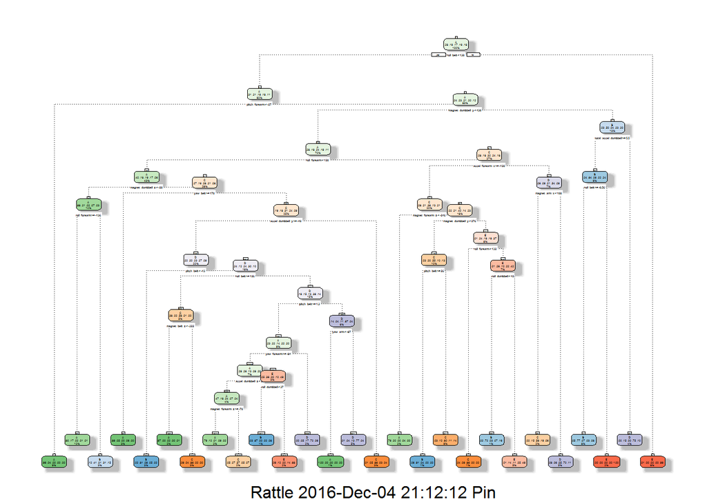

```r
library(rpart)
library(rpart.plot)
library(rattle)
modFit_dt<-rpart(classe ~ ., data=trainData, method="class")
fancyRpartPlot(modFit_dt)
```

```r
#rpart.plot(modFit_dt, main="Decision Tree", extra=102, under=TRUE, faclen=0)
prediction_dt<-predict(modFit_dt, valData, type = "class")
confusionMatrix(prediction_dt, valData$classe)
```

```
## $positive
## NULL
##
## $table
##           Reference
## Prediction    A    B    C    D    E
##          A 1536  182    7   52    8
##          B   53  690   58   80  103
##          C   41  106  854   99   99
##          D   29   79   71  629   72
##          E   15   82   36  104  800
##
## $overall
##       Accuracy          Kappa  AccuracyLower  AccuracyUpper   AccuracyNull
##   7.661852e-01   7.036375e-01   7.551560e-01   7.769499e-01   2.844520e-01
## AccuracyPValue  McnemarPValue
##   0.000000e+00   3.519254e-29
##
## $byClass
##          Sensitivity Specificity Pos Pred Value Neg Pred Value Precision
## Class: A   0.9175627   0.9408692      0.8605042      0.9663415 0.8605042
## Class: B   0.6057946   0.9380531      0.7012195      0.9083860 0.7012195
## Class: C   0.8323587   0.9289977      0.7122602      0.9632949 0.7122602
## Class: D   0.6524896   0.9489941      0.7147727      0.9330669 0.7147727
## Class: E   0.7393715   0.9506558      0.7714561      0.9418317 0.7714561
##             Recall        F1 Prevalence Detection Rate
## Class: A 0.9175627 0.8881180  0.2844520      0.2610025
## Class: B 0.6057946 0.6500236  0.1935429      0.1172472
## Class: C 0.8323587 0.7676404  0.1743415      0.1451147
## Class: D 0.6524896 0.6822126  0.1638063      0.1068819
## Class: E 0.7393715 0.7550731  0.1838573      0.1359388
##          Detection Prevalence Balanced Accuracy
## Class: A            0.3033135         0.9292159
## Class: B            0.1672048         0.7719238
## Class: C            0.2037383         0.8806782
## Class: D            0.1495327         0.8007419
## Class: E            0.1762107         0.8450137
##
## $mode
## [1] "sens_spec"
##
## $dots
## list()
##
## attr(,"class")
## [1] "confusionMatrix"
```

### Model 2: Random Forest

```r
library(randomForest)
modFit_rf <- randomForest(classe ~. , data=trainData)
prediction_rf <- predict(modFit_rf, valData, type = "class")
confusionMatrix(prediction_rf, valData$classe)
```

```
## $positive
## NULL
##
## $table
##           Reference
## Prediction    A    B    C    D    E
##          A 1674    8    0    0    0
##          B    0 1130    8    0    0
##          C    0    1 1017    4    3
##          D    0    0    1  958    3
##          E    0    0    0    2 1076
##
## $overall
##       Accuracy          Kappa  AccuracyLower  AccuracyUpper   AccuracyNull
##      0.9949023      0.9935509      0.9927306      0.9965580      0.2844520
## AccuracyPValue  McnemarPValue
##      0.0000000            NaN
##
## $byClass
##          Sensitivity Specificity Pos Pred Value Neg Pred Value Precision
## Class: A   1.0000000   0.9981002      0.9952438      1.0000000 0.9952438
## Class: B   0.9920983   0.9983144      0.9929701      0.9981041 0.9929701
## Class: C   0.9912281   0.9983536      0.9921951      0.9981481 0.9921951
## Class: D   0.9937759   0.9991872      0.9958420      0.9987812 0.9958420
## Class: E   0.9944547   0.9995836      0.9981447      0.9987518 0.9981447
##             Recall        F1 Prevalence Detection Rate
## Class: A 1.0000000 0.9976162  0.2844520      0.2844520
## Class: B 0.9920983 0.9925340  0.1935429      0.1920136
## Class: C 0.9912281 0.9917114  0.1743415      0.1728122
## Class: D 0.9937759 0.9948079  0.1638063      0.1627867
## Class: E 0.9944547 0.9962963  0.1838573      0.1828377
##          Detection Prevalence Balanced Accuracy
## Class: A            0.2858114         0.9990501
## Class: B            0.1933730         0.9952064
## Class: C            0.1741716         0.9947908
## Class: D            0.1634664         0.9964815
## Class: E            0.1831776         0.9970192
##
## $mode
## [1] "sens_spec"
##
## $dots
## list()
##
## attr(,"class")
## [1] "confusionMatrix"
```

**Random Forest model performs better than Decision Tree. Accuracy for Random Forest model was 0.995 compared to Decision Tree model with 0.766.**

### Out-of-sample error for random forest model

```r
outSampleError <- (1 - as.numeric(confusionMatrix(prediction_rf, valData$classe)$overall[1]))
outSampleError
```

```
## [1] 0.005097706
```

## Predict the testing dataset with random forest model

```r
finalPred<- predict(modFit_rf, testing, type="class")
finalPred
```

```
##  1  2  3  4  5  6  7  8  9 10 11 12 13 14 15 16 17 18 19 20
##  B  A  B  A  A  E  D  B  A  A  B  C  B  A  E  E  A  B  B  B
## Levels: A B C D E
```